# Returns for Stocks and Bonds under each Residential Party

This is a simple code for showing how stocks and bonds do when the presidential party is Democratic or Republican.

This code is 3 chunks: 1) Libraries 2) Read data 3) Plot!

Chunks 2 and 3 are each one call. You can execute by using `ctrl + shift + enter` after clicking inside the plot. Run the entire file by using `ctrl + alt + r`. You will most likely need to install packages for the first chunk.

Please recall that correlation != causation :)

### 1) Libraries

```r
# The usuals
library(readxl)     # for reading the ecxel file
library(tidyverse)  # all inclusive
library(here)       # for relative file paths
library(scales)     # for easy conversion of decimal to % in plots
```

### 2) Read Data

```r
# Load the data!
data <- read_xlsx(here("data_input/president-bond-stock-change-correlation.xlsx"),
  skip = 4
) %>%

  # excel saves spaces stupidly, so need this weird dot
  #  (don't ask how long i spent figuring this out)
  rename(
    stock_return = `S&P 500 Index `,
    year = ` Year`,
    bond_return = `100% Bonds `
  )
```

```
* `` -> ...26
```

### 3) Plots!

This whole chunk is really one call. I use `pmap`, but since I only have two lists, could have gotten away with `map2`. I found this easier for maintaining a clean workspace, and the code is not so lengthy or computationally heavy that any time is lost.

[figure not shown]

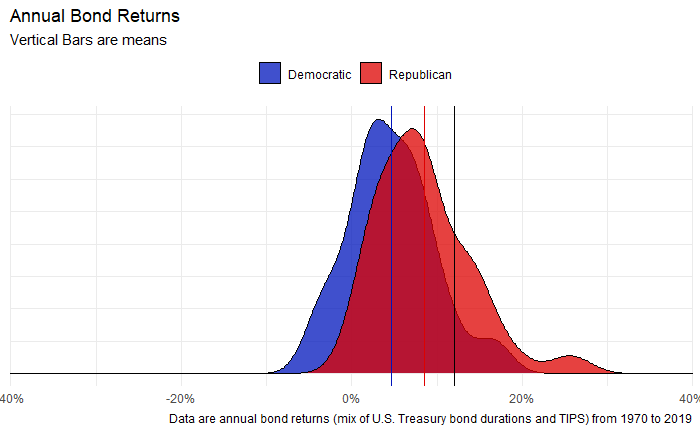

```r
# Plot!
pmap(

  # list the things I want to loop over
  .l = list(
    cols_to_plot <- c("stock_return", "bond_return"),
    names_to_plot <- c("Stock", "Bond")
  ),

  # and loop over them!
  .f = function(cols_to_plot, names_to_plot) {

    ## parameter set up:

    # official colors of Repub and Dem parties
    political_colors <- c("#0015BC", "#DE0100")

    # clean up the ggplot code later on by naming them now
    plot_title <- paste0("Annual ", names_to_plot, " Returns")

   ifelse(names_to_plot == "stock_return", data_source <- "S&P 500 returns", data_source <- "bond returns (mix of U.S. Treasury bond durations and TIPS)")

    plot_caption <- paste0(
      "Data are annual ",
      data_source,
      " from ",
      min(data$year),
      " to ",
      max(data$year)
    )

    # grab the means for each party for each asset class
    party_means <- data %>%
      select(Party, stock_return, bond_return) %>%
      group_by(Party) %>%
      summarize(
        stock_return = mean(stock_return),
        bond_return = mean(bond_return),
        .groups = "drop"
      ) %>%
      select(-Party) %>%
      identity()

    ### Plot #1: Boxplot
    data %>%
      ggplot(aes(x = Party, y = get(cols_to_plot))) +
      geom_boxplot(aes(fill = Party), width = 0.35) +
      geom_jitter(width = 0.05) +
      scale_fill_manual(values = political_colors) +
      scale_y_continuous(
        labels = percent_format(accuracy = 2),
        limits = c(-0.4, 0.4) # to match density plot and fix axis
      ) +
      theme_minimal() +
      labs(
        title = plot_title,
        caption = plot_caption
      ) +
      theme(
        legend.position = "none",
        axis.title = element_blank()
      ) +
      ggsave(filename = here(paste0("plots/box_", names_to_plot, ".png")))

    ### Plot #2: Density plot
    #    (2 = Repub, 1 = Dem)
    data %>%
      ggplot() +
      geom_density(aes(y = get(cols_to_plot), fill = Party), alpha = 0.75) +
      scale_fill_manual(values = political_colors) +
      coord_flip() +
      geom_hline(yintercept = mean(data$stock_return)) +
      geom_hline(yintercept = pull(party_means[1, cols_to_plot]), color = political_colors[1]) +
      geom_hline(yintercept = pull(party_means[2, cols_to_plot]), color = political_colors[2]) +
      theme_minimal() +
      theme(
        legend.position = "top",
        legend.title = element_blank(),
        axis.title = element_blank(),
        axis.text.y = element_blank()
      ) +
      scale_y_continuous(
        labels = percent_format(accuracy = 2),
        # goes in ylim because of flipped coordinates.
        limits = c(-0.4, 0.4),
        expand = expansion(mult=0)
      ) +
      labs(
        title = plot_title,
        subtitle = "Vertical Bars are means",
        caption = plot_caption
      ) +
      ggsave(filename = here(paste0("plots/density_", names_to_plot, ".png")))
  }
)
```